# Especiación continental de la codorniz común (*Coturnix coturnix*) en Marruecos

Valle Rodríguez Gil

2026-02-16

# 1 Introducción

En 2022, el equipo de investigación de Carles Vila publicó un artículo en el que se identificaba una **inversión de gran tamaño en el cromosoma 1 de la codorniz común (*Coturnix coturnix*)**, lo que daba lugar a dos morfotipos diferentes: uno sedentario con inversión y otro migratorio sin inversión.

El **morfotipo sedentario se encuentra geográficamente restringido al límite suroeste de la distribución de la especie**, incluyendo el sur de la Península Ibérica, el norte de África y los archipiélagos de la región de la Macaronesia (Illera et al., 2024). Dentro de esta línea de investigación, surge la pregunta de si puede estar ocurriendo, como consecuencia del aislamiento geográfico, una diferenciación fenotípica entre las codornices sedentarias que residen permanentemente en el continente y las codornices sedentarias que residen permanentemente en los archipiélagos (Gavrilets et al., 2000).

Específicamente **en las Islas Canarias y en Madeira**, no queda claro si existe realmente un aislamiento geográfico, ya que **algunas codornices del morfotipo migratorio procedentes del continente son desviadas por los vientos y terminan llegando a las islas más orientales**.

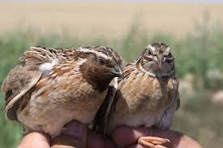

*Figura 1.1: Dos machos de codorniz común (C. coturnix) con diferente grado de pigmentación en la garganta*

La hipótesis principal de este proyecto plantea que las codornices con inversión cromosómica mostrarán diferencias morfológicas significativas según su origen, ya sean del continente o de los archipiélagos de Canarias y Madeira. Según las predicciones del síndrome insular y los resultados obtenido por otros estudios, se prevé de forma más concreta: (i) Las codornices procedentes de Madeira y Canarias tenderán a ser de mayor tamaño corporal que las del continente. (ii) Las codornices procedentes de Madeira y Canarias presentarán una colorimetría y un patrón de plumaje mucho más oscuro que las del continente. (iii) Las codornices procedentes de Madeira y Canarias mostrarán una disminución en los niveles de grasa corporal (relacionada con el impulso migrador). (iv) Las codornices de Madeira y Canarias presentarán un aparato de vuelo menos eficiente que las del continente.

Para conocer más información sobre la especie, dejamos el siguiente enlace a una [ficha hecha por SEO](https://seo.org/ave/codorniz-comun/).

# 2 Metodología

## 2.1 Área de estudio

El área de captura de machos de codorniz común comprendió varias localidades del sur de Europa, del norte de África y de la región de la Macaronesia. Estas quedan representadas en Figura 2.1.

[interactive chart not shown]

Figure 2.1: Mapa de Europa y del norte de África con las localizaciones específicas donde se capturaron codornices comunes (C. coturnix) entre 2008 y 2019. Los puntos rojos representan las localizaciones correspondientes a isla, y los puntos azules las localizaciones correspondientes a continente.

## 2.2 Toma de medidas

Los machos de codorniz común que se han utilizado en este estudio fueron capturados entre los años 2008 y 2019, siempre durante la época reproductiva (marzo-junio). Para las capturas se empleó una red japonesa o de niebla, y se realizó como máximo un muestreo por semana, aunque no de manera constante.

Ningún ave sufrió daño alguno durante la captura y manejo, los procedimientos se ajustaron a las directrices y regulaciones institucionales y nacionales pertinentes en bioética.

Table 2.1: Valores promedios de los datos recogidos en las localidades de Continente y en las localidades de Isla

| Variables | Valores_promedio_Continente | Valores_promedio_Isla |
| --- | --- | --- |
| Peso | 101.00 | 100.00 |
| Longitud del tarso | 33.52 | 32.78 |
| Longitud ala plegada | 10.90 | 10.90 |
| Flancos | 1.58 | 2.00 |
| Índice de Holynski | 122.00 | 121.00 |
| Banda lipídica | 1.88 | 2.73 |

## 2.3 Análisis estadístico

```r
datos <- datos |>
  mutate(Sitio = ifelse(loc1 %in% c("Marruecos", "Portugal", "Sevilla"), "Continente", "Isla"))

# Solo BB Eu5
datos_filtradosBB <- datos |>
  filter(genotipo == "BB" & euring == 4)

# Solo AB Eu5
datos_filtradosAB <- datos |>
  filter(genotipo == "AB" & euring == 4)
#Ahora prefiero los euring 4
```

# 3 Resultados

[figure not shown]

# Referencias

Gavrilets, S., Acton, R., & Gravner, J. (2000). DYNAMICS OF SPECIATION AND DIVERSIFICATION IN A METAPOPULATION. *Evolution*, *54*(5), 1493–1501. https://doi.org/10.1111/j.0014-3820.2000.tb00695.x

Illera, J. C., Rando, J. C., Melo, M., Valente, L., & Stervander, M. (2024). Avian Island Radiations Shed Light on the Dynamics of Adaptive and Nonadaptive Radiation. *Cold Spring Harbor Perspectives in Biology*, *16*(12), a041451. https://doi.org/10.1101/cshperspect.a041451